# Customer Lifetime Value Prediction

### policy

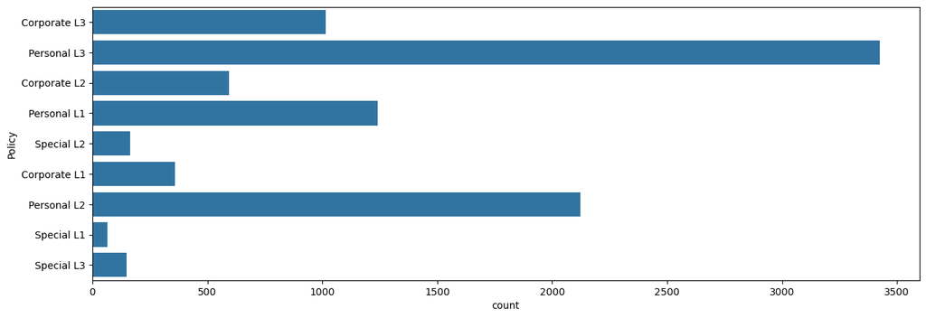

```python
plt.figure(figsize=(15,5))
sns.countplot(df["Policy"])
plt.show()
```

Personal L3 policy subcategory has the most number of customers

### Renew Offer type

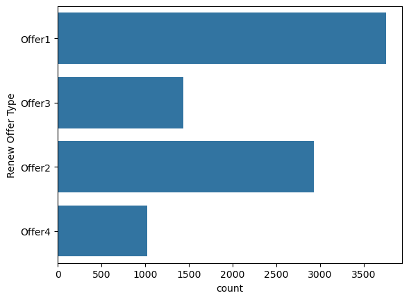

```python
sns.countplot(df["Renew Offer Type"])
plt.show()
```

### Sales Channel

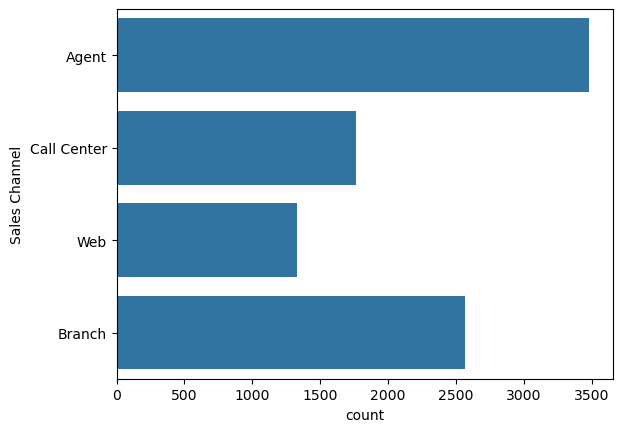

```python
sns.countplot(df["Sales Channel"])
plt.show()
```

### Vehicle Class

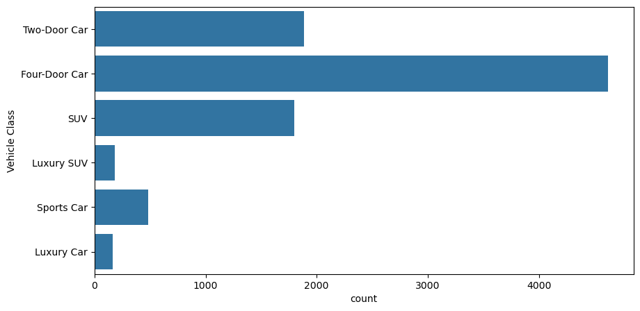

```python
plt.figure(figsize=(10,5))
sns.countplot(df["Vehicle Class"])
plt.show()
```

### Vehicle Size

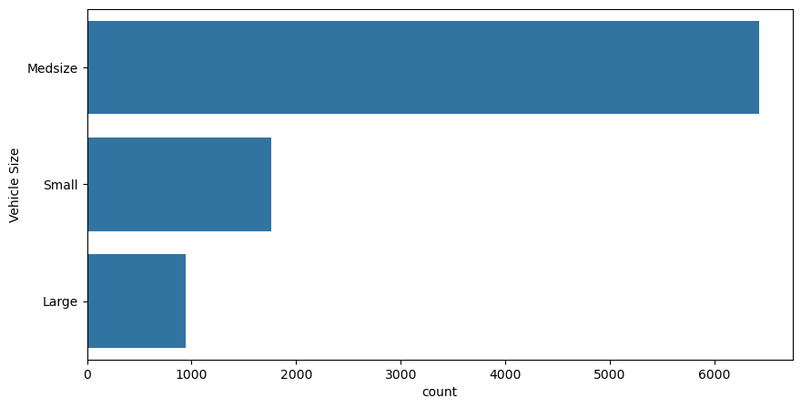

```python
plt.figure(figsize=(10,5))
sns.countplot(df["Vehicle Size"])
plt.show()
```

### Number of Open Complaints

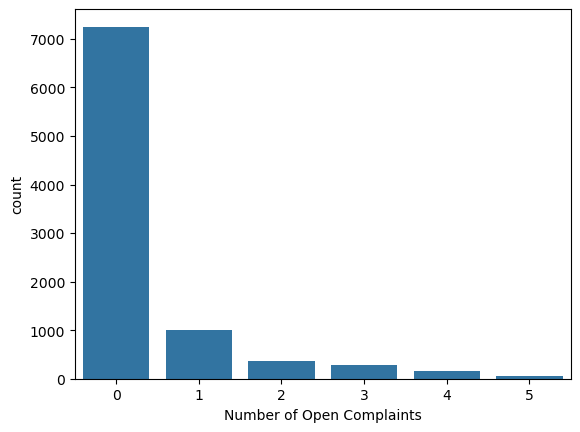

```python
sns.countplot(df, x="Number of Open Complaints")
plt.show()
```

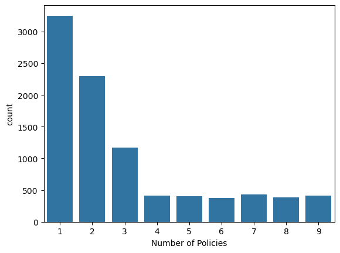

```python
sns.countplot(df, x="Number of Policies")
plt.show()
```

```python
df['Effective To Date']=pd.to_datetime(df['Effective To Date'],infer_datetime_format=True)
```

```python
df["Months"] = df["Effective To Date"].dt.month
```

```python
df['Months'] = df['Months'].astype('object')
```

### Months

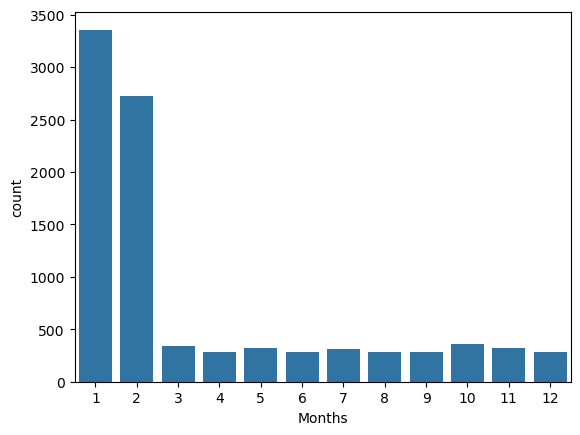

```python
sns.countplot(df, x="Months")
```

```python
cat_cols.columns
```

```
Index(['Customer', 'State', 'Response', 'Coverage', 'Education',
       'EmploymentStatus', 'Gender', 'Location Code', 'Marital Status',
       'Policy Type', 'Policy', 'Renew Offer Type', 'Sales Channel',
       'Vehicle Class', 'Vehicle Size', 'Number of Open Complaints',
       'Number of Policies'],
      dtype='object')
```

```python
df.columns
```

```
Index(['Customer', 'State', 'CLV', 'Response', 'Coverage', 'Education',
       'Effective To Date', 'EmploymentStatus', 'Gender', 'Income',
       'Location Code', 'Marital Status', 'Monthly Premium Auto',
       'Months Since Last Claim', 'Months Since Policy Inception',
       'Number of Open Complaints', 'Number of Policies', 'Policy Type',
       'Policy', 'Renew Offer Type', 'Sales Channel', 'Total Claim Amount',
       'Vehicle Class', 'Vehicle Size', 'Months'],
      dtype='object')
```

### HeatMap

```python
heatmap = df[['CLV', 'Income', 'Monthly Premium Auto','Total Claim Amount']]
```

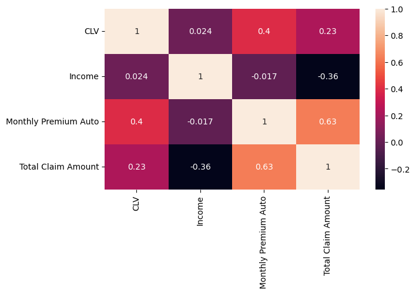

```python
plt.figure(figsize=(7,4))
sns.heatmap(heatmap.corr(),annot=True)
# plt.savefig("Heatmap.png")
plt.show()
```

We can clearly see in the heatmap, that customer lifetime value has a better correlation with monthly premium auto and acceptable correlation with total claim amount.

### Statistical Significance

- H0:The null hypothesis of the test is the data is normally distributed
- HA:The data is not normally distributed

```python
stats.shapiro(df['CLV'])
```

```
ShapiroResult(statistic=0.7033725380897522, pvalue=0.0)
```

p-value less than 0.05 we reject null hypothesis the data is not normally distributed

We will proceed with non parametric tests since the dependent variable is not normally distributed

```python
columns_cat = list(cat_cols.columns)
columns_cat
```

```
['Customer',
 'State',
 'Response',
 'Coverage',
 'Education',
 'EmploymentStatus',
 'Gender',
 'Location Code',
 'Marital Status',
 'Policy Type',
 'Policy',
 'Renew Offer Type',
 'Sales Channel',
 'Vehicle Class',
 'Vehicle Size',
 'Number of Open Complaints',
 'Number of Policies']
```

```python
manwhiteneyy = []
anova = []

for i in columns_cat:
    if (df[i].nunique()>2):
        anova.append(i)
    else:
        manwhiteneyy.append(i)
print("Anova:",anova)
print("TTest:",manwhiteneyy)
```

```
Anova: ['Customer', 'State', 'Coverage', 'Education', 'EmploymentStatus', 'Location Code', 'Marital Status', 'Policy Type', 'Policy', 'Renew Offer Type', 'Sales Channel', 'Vehicle Class', 'Vehicle Size', 'Number of Open Complaints', 'Number of Policies']
TTest: ['Response', 'Gender']
```

H0, the distributions of both populations are equal The alternative hypothesis H1 is that the distributions are not equal.

```python
yes=df[df['Response']=='No']['CLV']
no=df[df['Response']=='Yes']['CLV']
```

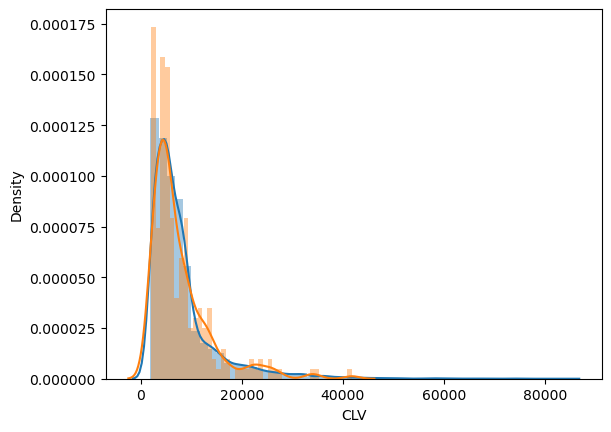

```python
sns.distplot(yes)
sns.distplot(no)
```

If the distributions are identical, which is the null hypothesis of the Mann-Whitney U test, the mean rank will be the same

```python
f = stats.mannwhitneyu(yes,no)
print(f)
```

```
MannwhitneyuResult(statistic=5175420.0, pvalue=0.5168872245291198)
```

```python
male=df[df['Gender']=='M']['CLV']
female=df[df['Gender']=='F']['CLV']
```

```python
b =stats.mannwhitneyu(male,female)
print(b)
```

```
MannwhitneyuResult(statistic=10337134.0, pvalue=0.48749303056449833)
```

p-value is greater than 0.05 we failed to reject null hypothesis i.e the mean rank will be the same for both males and females.

we test above two features with non-Paramteric unpaired ttest and we concluded that those 2 features is not significant to predict traget

- H0:the mean ranks of the groups are the same.
- H1:the mean ranks of the groups are not the same.

```python
ca=df[df['State']=='California']['CLV']
Or=df[df['State']=='Oregon']['CLV']
Ar=df[df['State']=='Arizona']['CLV']
Ne=df[df['State']=='Nevada']['CLV']
Wa=df[df['State']=='Washington']['CLV']
```

```python
a = stats.kruskal(ca,Or,Ar,Ne,Wa)
print(a)
```

```
KruskalResult(statistic=5.072069583836472, pvalue=0.27998232358818953)
```

p-value > 0.05 failed to reject H0

```python
stats.f_oneway(ca,Or,Ar,Ne,Wa)
print(b)
```

```
MannwhitneyuResult(statistic=10337134.0, pvalue=0.48749303056449833)
```

```python
Ba=df[df['Coverage']=='Basic']['CLV']
Ex=df[df['Coverage']=='Extended']['CLV']
Pr=df[df['Coverage']=='Premium']['CLV']
```

[output not shown]

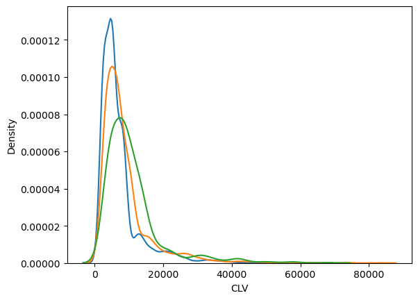

```python
sns.distplot(Ba,hist=False,label='Basic')
sns.distplot(Ex,hist=False)
sns.distplot(Pr,hist=False)
plt.show()
```

```python
c =stats.kruskal(Ba,Ex,Pr)
print(c)
```

```
KruskalResult(statistic=502.4996090762843, pvalue=7.648852917746348e-110)
```

p-value < 0.05 to reject H0

```python
stats.f_oneway(Ba,Ex,Pr)
```

```
F_onewayResult(statistic=133.67511419504905, pvalue=6.0158970099807e-58)
```

```python
Ba=df[df['Education']=='Bachelor']['CLV']
Co=df[df['Education']=='College']['CLV']
Hi=df[df['Education']=='High School or Below']['CLV']
Ma=df[df['Education']=='Master']['CLV']
Da=df[df['Education']=='Doctor']['CLV']
```

```python
d= stats.kruskal(Ba,Co,Hi,Ma,Da)
print(d)
```

```
KruskalResult(statistic=12.234061758188824, pvalue=0.015693004298603028)
```

[output not shown]

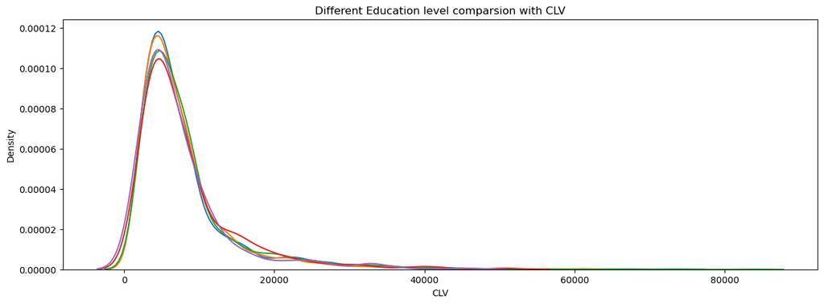

```python
plt.figure(figsize=(15,5))
sns.distplot(Ba,hist=False,label='Bachelor')
sns.distplot(Co,hist=False,label='College')
sns.distplot(Hi,hist=False,label='High School or Below')
sns.distplot(Ma,hist=False,label='Master')
sns.distplot(Da,hist=False,label='Doctor')
plt.title("Different Education level comparsion with CLV")
# plt.savefig("Education.png")
plt.show()
```

p-value < 0.05 reject H0, Education is significant in predicting CLV

```python
Ba=df[df['EmploymentStatus']=='Employed']['CLV']
Co=df[df['EmploymentStatus']=='Unemployed']['CLV']
Hi=df[df['EmploymentStatus']=='Medical Leave']['CLV']
Ma=df[df['EmploymentStatus']=='Disabled']['CLV']
Da=df[df['EmploymentStatus']=='Retired']['CLV']
```

```python
e = stats.kruskal(Ba,Co,Hi,Ma,Da)
print(e)
```

```
KruskalResult(statistic=42.56159302970864, pvalue=1.2758458797542519e-08)
```

p-value < 0.05 reject H0, EmploymentStatus is significant in predicting CLV

```python
Ba=df[df['Location Code']=='Suburban']['CLV']
Co=df[df['Location Code']=='Rural']['CLV']
Hi=df[df['Location Code']=='Urban']['CLV']
```

```python
g = stats.kruskal(Ba,Co,Hi)
print(g)
```

```
KruskalResult(statistic=2.4638212999332567, pvalue=0.29173464205664124)
```

```python
Ba=df[df['Marital Status']=='Married']['CLV']
Co=df[df['Marital Status']=='Single']['CLV']
Hi=df[df['Marital Status']=='Divorced']['CLV']
```

```python
h = stats.kruskal(Ba,Co,Hi)
print(h)
```

```
KruskalResult(statistic=20.895798766808223, pvalue=2.9009146434700455e-05)
```

p-value < 0.05 reject H0, Marital Status can be significant in predicting CLV

```python
Ba=df[df['Number of Open Complaints']==0]['CLV']
Co=df[df['Number of Open Complaints']==1]['CLV']
Hi=df[df['Number of Open Complaints']==2]['CLV']
Ma=df[df['Number of Open Complaints']==3]['CLV']
Da=df[df['Number of Open Complaints']==4]['CLV']
As=df[df['Number of Open Complaints']==5]['CLV']
```

```python
o = stats.kruskal(Ba,Co,Hi,Ma,Da,As)
print(o)
```

```
KruskalResult(statistic=29.160617988301833, pvalue=2.1564409504417123e-05)
```

p-value < 0.05 reject H0, Number of Open Complaints can be significant in predicting CLV

```python
Ba=df[df['Number of Policies']==1]['CLV']
Co=df[df['Number of Policies']==2]['CLV']
Hi=df[df['Number of Policies']==3]['CLV']
```

```python
p = stats.kruskal(Ba,Co,Hi)
print(p)
```

```
KruskalResult(statistic=5017.7060662040785, pvalue=0.0)
```

p-value < 0.05 reject H0, Number of Policies can be significant in predicting CLV

```python
Ba=df[df['Policy Type']=='Personal Auto']['CLV']
Co=df[df['Policy Type']=='Corporate Auto']['CLV']
Hi=df[df['Policy Type']=='Special Auto']['CLV']
```

```python
i = stats.kruskal(Ba,Co,Hi)
print(i)
```

```
KruskalResult(statistic=4.6074986354931795, pvalue=0.0998836452694168)
```

p-value > 0.05 failed to reject H0, Policy Type may not be significant in predicting CLV

```python
Ba=df[df['Policy']=='Personal L3']['CLV']
Co=df[df['Policy']=='Personal L2']['CLV']
Hi=df[df['Policy']=='Personal L1']['CLV']
Ma=df[df['Policy']=='Corporate L3']['CLV']
Da=df[df['Policy']=='Corporate L2']['CLV']
Ca=df[df['Policy']=='Corporate L1']['CLV']
s1=df[df['Policy']=='Special L2']['CLV']
s2=df[df['Policy']=='Special L3']['CLV']
s3=df[df['Policy']=='Special L1']['CLV']
```

```python
j =stats.kruskal(Ba,Co,Hi,Ma,Da,Ca,s1,s2,s3)
print(j)
```

```
KruskalResult(statistic=7.944351884462466, pvalue=0.4389248352544014)
```

p-value > 0.05 failed to reject H0, Policy may not be significant in predicting CLV

```python
Ba=df[df['Renew Offer Type']=='Offer1']['CLV']
Co=df[df['Renew Offer Type']=='Offer2']['CLV']
Hi=df[df['Renew Offer Type']=='Offer3']['CLV']
Ma=df[df['Renew Offer Type']=='Offer4']['CLV']
```

```python
k =stats.kruskal(Ba,Co,Hi,Ma)
print(k)
```

```
KruskalResult(statistic=168.90219457792458, pvalue=2.196144881912684e-36)
```

```python
Ba=df[df['Sales Channel']=='Agent']['CLV']
Co=df[df['Sales Channel']=='Branch']['CLV']
Hi=df[df['Sales Channel']=='Call Center']['CLV']
Ma=df[df['Sales Channel']=='Web']['CLV']
```

```python
l = stats.kruskal(Ba,Co,Hi,Ma)
print(l)
```

```
KruskalResult(statistic=4.491751501229693, pvalue=0.2130272157209903)
```

p-value > 0.05 failed to reject H0, Sales Channel may not be significant in predicting CLV

```python
Ba=df[df['Vehicle Class']=='Four-Door Car']['CLV']
Co=df[df['Vehicle Class']=='Two-Door Car']['CLV']
Hi=df[df['Vehicle Class']=='SUV']['CLV']
Ma=df[df['Vehicle Class']=='Sports Car']['CLV']
Da=df[df['Vehicle Class']=='Luxury SUV']['CLV']
Ca=df[df['Vehicle Class']=='Luxury Car']['CLV']
```

```python
m = stats.kruskal(Ba,Co,Hi,Ma,Da,Ca)
print(m)
```

```
KruskalResult(statistic=1310.5494960284416, pvalue=3.309676344717952e-281)
```

p-value < 0.05 reject H0, Vehicle Class can be significant in predicting CLV

```python
Ba=df[df['Vehicle Size']=='Medsize']['CLV']
Co=df[df['Vehicle Size']=='Small']['CLV']
Hi=df[df['Vehicle Size']=='Large']['CLV']
```

```python
n =stats.kruskal(Ba,Co,Hi)
print(n)
```

```
KruskalResult(statistic=9.564995661218877, pvalue=0.00837505335446059)
```

```python
columns_cat
```

```
['Customer',
 'State',
 'Response',
 'Coverage',
 'Education',
 'EmploymentStatus',
 'Gender',
 'Location Code',
 'Marital Status',
 'Policy Type',
 'Policy',
 'Renew Offer Type',
 'Sales Channel',
 'Vehicle Class',
 'Vehicle Size',
 'Number of Open Complaints',
 'Number of Policies']
```

```python
cat_cols.drop("Customer",axis=1,inplace=True)
```

```python
cat_cols
```

|  | State | Response | Coverage | Education | EmploymentStatus | Gender | Location Code | Marital Status | Policy Type | Policy | Renew Offer Type | Sales Channel | Vehicle Class | Vehicle Size | Number of Open Complaints | Number of Policies |
| --- | --- | --- | --- | --- | --- | --- | --- | --- | --- | --- | --- | --- | --- | --- | --- | --- |
| 0 | Washington | No | Basic | Bachelor | Employed | F | Suburban | Married | Corporate Auto | Corporate L3 | Offer1 | Agent | Two-Door Car | Medsize | 0 | 1 |
| 1 | Arizona | No | Extended | Bachelor | Unemployed | F | Suburban | Single | Personal Auto | Personal L3 | Offer3 | Agent | Four-Door Car | Medsize | 0 | 8 |
| 2 | Nevada | No | Premium | Bachelor | Employed | F | Suburban | Married | Personal Auto | Personal L3 | Offer1 | Agent | Two-Door Car | Medsize | 0 | 2 |
| 3 | California | No | Basic | Bachelor | Unemployed | M | Suburban | Married | Corporate Auto | Corporate L2 | Offer1 | Call Center | SUV | Medsize | 0 | 7 |
| 4 | Washington | No | Basic | Bachelor | Employed | M | Rural | Single | Personal Auto | Personal L1 | Offer1 | Agent | Four-Door Car | Medsize | 0 | 1 |
| ... | ... | ... | ... | ... | ... | ... | ... | ... | ... | ... | ... | ... | ... | ... | ... | ... |
| 9129 | California | No | Basic | Bachelor | Employed | M | Urban | Married | Personal Auto | Personal L1 | Offer2 | Web | Four-Door Car | Medsize | 0 | 2 |
| 9130 | California | Yes | Extended | College | Employed | F | Suburban | Divorced | Corporate Auto | Corporate L3 | Offer1 | Branch | Four-Door Car | Medsize | 0 | 1 |
| 9131 | California | No | Extended | Bachelor | Unemployed | M | Suburban | Single | Corporate Auto | Corporate L2 | Offer1 | Branch | Four-Door Car | Medsize | 3 | 2 |
| 9132 | California | No | Extended | College | Employed | M | Suburban | Married | Personal Auto | Personal L2 | Offer3 | Branch | Four-Door Car | Large | 0 | 3 |
| 9133 | California | No | Extended | College | Unemployed | M | Suburban | Single | Corporate Auto | Corporate L3 | Offer4 | Call Center | Two-Door Car | Medsize | 0 | 1 |

9134 rows × 16 columns

```python
p_values = [a[1],b[1],c[1],d[1],e[1],f[1],g[1],h[1],i[1],j[1],k[1],l[1],m[1],n[1],o[1],p[1]]
```

```python
p_values
```

```
[0.27998232358818953,
 0.48749303056449833,
 7.648852917746348e-110,
 0.015693004298603028,
 1.2758458797542519e-08,
 0.5168872245291198,
 0.29173464205664124,
 2.9009146434700455e-05,
 0.0998836452694168,
 0.4389248352544014,
 2.196144881912684e-36,
 0.2130272157209903,
 3.309676344717952e-281,
 0.00837505335446059,
 2.1564409504417123e-05,
 0.0]
```

```python
len(p_values)
```

```
16
```

```python
pd.DataFrame(p_values,index=(cat_cols.columns),columns=['P_Value'])
```

|  | P_Value |
| --- | --- |
| State | 2.799823e-01 |
| Response | 4.874930e-01 |
| Coverage | 7.648853e-110 |
| Education | 1.569300e-02 |
| EmploymentStatus | 1.275846e-08 |
| Gender | 5.168872e-01 |
| Location Code | 2.917346e-01 |
| Marital Status | 2.900915e-05 |
| Policy Type | 9.988365e-02 |
| Policy | 4.389248e-01 |
| Renew Offer Type | 2.196145e-36 |
| Sales Channel | 2.130272e-01 |
| Vehicle Class | 3.309676e-281 |
| Vehicle Size | 8.375053e-03 |
| Number of Open Complaints | 2.156441e-05 |
| Number of Policies | 0.000000e+00 |

Coverage,Education,EmploymentStatus,Marital Status, Renew Offer Type, Vehicle class, Vehicle class, Number of open complaints and No of Policies play a significant role in predicting the CLV

```python
numerical_cols.head()
```

|  | CLV | Income | Monthly Premium Auto | Months Since Last Claim | Months Since Policy Inception | Total Claim Amount |
| --- | --- | --- | --- | --- | --- | --- |
| 0 | 2763.519279 | 56274 | 69 | 32 | 5 | 384.811147 |
| 1 | 6979.535903 | 0 | 94 | 13 | 42 | 1131.464935 |
| 2 | 12887.431650 | 48767 | 108 | 18 | 38 | 566.472247 |
| 3 | 7645.861827 | 0 | 106 | 18 | 65 | 529.881344 |
| 4 | 2813.692575 | 43836 | 73 | 12 | 44 | 138.130879 |

```python
cat_cols.head()
```

|  | State | Response | Coverage | Education | EmploymentStatus | Gender | Location Code | Marital Status | Policy Type | Policy | Renew Offer Type | Sales Channel | Vehicle Class | Vehicle Size | Number of Open Complaints | Number of Policies |
| --- | --- | --- | --- | --- | --- | --- | --- | --- | --- | --- | --- | --- | --- | --- | --- | --- |
| 0 | Washington | No | Basic | Bachelor | Employed | F | Suburban | Married | Corporate Auto | Corporate L3 | Offer1 | Agent | Two-Door Car | Medsize | 0 | 1 |
| 1 | Arizona | No | Extended | Bachelor | Unemployed | F | Suburban | Single | Personal Auto | Personal L3 | Offer3 | Agent | Four-Door Car | Medsize | 0 | 8 |
| 2 | Nevada | No | Premium | Bachelor | Employed | F | Suburban | Married | Personal Auto | Personal L3 | Offer1 | Agent | Two-Door Car | Medsize | 0 | 2 |
| 3 | California | No | Basic | Bachelor | Unemployed | M | Suburban | Married | Corporate Auto | Corporate L2 | Offer1 | Call Center | SUV | Medsize | 0 | 7 |
| 4 | Washington | No | Basic | Bachelor | Employed | M | Rural | Single | Personal Auto | Personal L1 | Offer1 | Agent | Four-Door Car | Medsize | 0 | 1 |

```python
# X=numerical_cols.drop(['CLV'],axis=1)
# y=numerical_cols['CLV']
# lin_reg=sm.OLS(y,X).fit()
# lin_reg.summary()
```

## Data Preprocessing

```python
cat_cols.head()
```

|  | State | Response | Coverage | Education | EmploymentStatus | Gender | Location Code | Marital Status | Policy Type | Policy | Renew Offer Type | Sales Channel | Vehicle Class | Vehicle Size | Number of Open Complaints | Number of Policies |
| --- | --- | --- | --- | --- | --- | --- | --- | --- | --- | --- | --- | --- | --- | --- | --- | --- |
| 0 | Washington | No | Basic | Bachelor | Employed | F | Suburban | Married | Corporate Auto | Corporate L3 | Offer1 | Agent | Two-Door Car | Medsize | 0 | 1 |
| 1 | Arizona | No | Extended | Bachelor | Unemployed | F | Suburban | Single | Personal Auto | Personal L3 | Offer3 | Agent | Four-Door Car | Medsize | 0 | 8 |
| 2 | Nevada | No | Premium | Bachelor | Employed | F | Suburban | Married | Personal Auto | Personal L3 | Offer1 | Agent | Two-Door Car | Medsize | 0 | 2 |
| 3 | California | No | Basic | Bachelor | Unemployed | M | Suburban | Married | Corporate Auto | Corporate L2 | Offer1 | Call Center | SUV | Medsize | 0 | 7 |
| 4 | Washington | No | Basic | Bachelor | Employed | M | Rural | Single | Personal Auto | Personal L1 | Offer1 | Agent | Four-Door Car | Medsize | 0 | 1 |

```python
catg=pd.get_dummies(cat_cols,drop_first=True)
```

```python
numerical_cols.head()
```

|  | CLV | Income | Monthly Premium Auto | Months Since Last Claim | Months Since Policy Inception | Total Claim Amount |
| --- | --- | --- | --- | --- | --- | --- |
| 0 | 2763.519279 | 56274 | 69 | 32 | 5 | 384.811147 |
| 1 | 6979.535903 | 0 | 94 | 13 | 42 | 1131.464935 |
| 2 | 12887.431650 | 48767 | 108 | 18 | 38 | 566.472247 |
| 3 | 7645.861827 | 0 | 106 | 18 | 65 | 529.881344 |
| 4 | 2813.692575 | 43836 | 73 | 12 | 44 | 138.130879 |

```python
dfn = pd.concat([numerical_cols,catg],axis=1)
dfn.head()
```

|  | CLV | Income | Monthly Premium Auto | Months Since Last Claim | Months Since Policy Inception | Total Claim Amount | Number of Open Complaints | Number of Policies | State_California | State_Nevada | ... | Sales Channel_Branch | Sales Channel_Call Center | Sales Channel_Web | Vehicle Class_Luxury Car | Vehicle Class_Luxury SUV | Vehicle Class_SUV | Vehicle Class_Sports Car | Vehicle Class_Two-Door Car | Vehicle Size_Medsize | Vehicle Size_Small |
| --- | --- | --- | --- | --- | --- | --- | --- | --- | --- | --- | --- | --- | --- | --- | --- | --- | --- | --- | --- | --- | --- |
| 0 | 2763.519279 | 56274 | 69 | 32 | 5 | 384.811147 | 0 | 1 | 0 | 0 | ... | 0 | 0 | 0 | 0 | 0 | 0 | 0 | 1 | 1 | 0 |
| 1 | 6979.535903 | 0 | 94 | 13 | 42 | 1131.464935 | 0 | 8 | 0 | 0 | ... | 0 | 0 | 0 | 0 | 0 | 0 | 0 | 0 | 1 | 0 |
| 2 | 12887.431650 | 48767 | 108 | 18 | 38 | 566.472247 | 0 | 2 | 0 | 1 | ... | 0 | 0 | 0 | 0 | 0 | 0 | 0 | 1 | 1 | 0 |
| 3 | 7645.861827 | 0 | 106 | 18 | 65 | 529.881344 | 0 | 7 | 1 | 0 | ... | 0 | 1 | 0 | 0 | 0 | 1 | 0 | 0 | 1 | 0 |
| 4 | 2813.692575 | 43836 | 73 | 12 | 44 | 138.130879 | 0 | 1 | 0 | 0 | ... | 0 | 0 | 0 | 0 | 0 | 0 | 0 | 0 | 1 | 0 |

5 rows × 51 columns

## OLS Model

```python
dfn.rename(columns={'CLV':'CLV'},inplace=True)
```

```python
X=dfn.drop(['CLV'],axis=1)
y=dfn['CLV']
X_constant=sm.add_constant(X)
lin_reg=sm.OLS(y,X_constant).fit()
lin_reg.summary()
```

OLS Regression Results

| Dep. Variable: | CLV | R-squared: | 0.169 |
| --- | --- | --- | --- |
| Model: | OLS | Adj. R-squared: | 0.165 |
| Method: | Least Squares | F-statistic: | 38.60 |
| Date: | Wed, 06 Mar 2024 | Prob (F-statistic): | 6.92e-323 |
| Time: | 09:31:35 | Log-Likelihood: | -92812. |
| No. Observations: | 9134 | AIC: | 1.857e+05 |
| Df Residuals: | 9085 | BIC: | 1.861e+05 |
| Df Model: | 48 |  |  |
| Covariance Type: | nonrobust |  |  |

|  | coef | std err | t | P>\|t\| | [0.025 | 0.975] |
| --- | --- | --- | --- | --- | --- | --- |
| const | 1486.6386 | 903.661 | 1.645 | 0.100 | -284.740 | 3258.017 |
| Income | -0.0012 | 0.004 | -0.307 | 0.759 | -0.009 | 0.006 |
| Monthly Premium Auto | 69.5779 | 10.026 | 6.940 | 0.000 | 49.926 | 89.230 |
| Months Since Last Claim | 7.0626 | 6.554 | 1.078 | 0.281 | -5.785 | 19.911 |
| Months Since Policy Inception | -1.3200 | 2.380 | -0.555 | 0.579 | -5.985 | 3.345 |
| Total Claim Amount | -0.2268 | 0.474 | -0.478 | 0.632 | -1.156 | 0.703 |
| Number of Open Complaints | -264.2647 | 72.496 | -3.645 | 0.000 | -406.373 | -122.157 |
| Number of Policies | 57.7126 | 27.753 | 2.080 | 0.038 | 3.311 | 112.114 |
| State_California | 39.9647 | 189.426 | 0.211 | 0.833 | -331.354 | 411.283 |
| State_Nevada | 45.7021 | 261.160 | 0.175 | 0.861 | -466.231 | 557.635 |
| State_Oregon | 84.9912 | 196.050 | 0.434 | 0.665 | -299.312 | 469.294 |
| State_Washington | 164.3324 | 269.980 | 0.609 | 0.543 | -364.888 | 693.553 |
| Response_Yes | -215.9162 | 207.436 | -1.041 | 0.298 | -622.538 | 190.705 |
| Coverage_Extended | 130.1678 | 249.287 | 0.522 | 0.602 | -358.490 | 618.826 |
| Coverage_Premium | 61.7491 | 527.605 | 0.117 | 0.907 | -972.476 | 1095.974 |
| Education_College | -1.5962 | 171.219 | -0.009 | 0.993 | -337.225 | 334.032 |
| Education_Doctor | -197.9744 | 362.976 | -0.545 | 0.585 | -909.488 | 513.540 |
| Education_High School or Below | 388.9735 | 173.415 | 2.243 | 0.025 | 49.041 | 728.906 |
| Education_Master | 157.9503 | 262.899 | 0.601 | 0.548 | -357.390 | 673.291 |
| EmploymentStatus_Employed | 700.4418 | 354.477 | 1.976 | 0.048 | 5.587 | 1395.296 |
| EmploymentStatus_Medical Leave | 210.8226 | 436.143 | 0.483 | 0.629 | -644.116 | 1065.761 |
| EmploymentStatus_Retired | 64.6393 | 502.732 | 0.129 | 0.898 | -920.829 | 1050.108 |
| EmploymentStatus_Unemployed | 9.1563 | 357.613 | 0.026 | 0.980 | -691.846 | 710.158 |
| Gender_M | -143.5239 | 132.973 | -1.079 | 0.280 | -404.181 | 117.133 |
| Location Code_Suburban | -73.7895 | 263.381 | -0.280 | 0.779 | -590.076 | 442.497 |
| Location Code_Urban | 128.8756 | 241.416 | 0.534 | 0.593 | -344.355 | 602.106 |
| Marital Status_Married | -177.6388 | 194.800 | -0.912 | 0.362 | -559.490 | 204.212 |
| Marital Status_Single | -490.7108 | 225.714 | -2.174 | 0.030 | -933.161 | -48.260 |
| Policy Type_Personal Auto | -305.6726 | 256.741 | -1.191 | 0.234 | -808.943 | 197.598 |
| Policy Type_Special Auto | 165.6132 | 362.670 | 0.457 | 0.648 | -545.301 | 876.527 |
| Policy_Corporate L2 | -1007.2895 | 420.508 | -2.395 | 0.017 | -1831.581 | -182.998 |
| Policy_Corporate L3 | -668.9524 | 386.386 | -1.731 | 0.083 | -1426.357 | 88.452 |
| Policy_Personal L1 | -161.3307 | 163.621 | -0.986 | 0.324 | -482.065 | 159.404 |
| Policy_Personal L2 | -6.5954 | 141.822 | -0.047 | 0.963 | -284.598 | 271.408 |
| Policy_Personal L3 | -137.7465 | 128.664 | -1.071 | 0.284 | -389.957 | 114.464 |
| Policy_Special L1 | 27.9113 | 613.988 | 0.045 | 0.964 | -1175.643 | 1231.465 |
| Policy_Special L2 | -334.1257 | 443.941 | -0.753 | 0.452 | -1204.351 | 536.099 |
| Policy_Special L3 | 471.8275 | 458.306 | 1.030 | 0.303 | -426.556 | 1370.211 |
| Renew Offer Type_Offer2 | -965.7715 | 165.363 | -5.840 | 0.000 | -1289.920 | -641.623 |
| Renew Offer Type_Offer3 | -535.2550 | 200.282 | -2.673 | 0.008 | -927.853 | -142.657 |
| Renew Offer Type_Offer4 | -1196.6484 | 233.357 | -5.128 | 0.000 | -1654.080 | -739.217 |
| Sales Channel_Branch | 227.6845 | 164.822 | 1.381 | 0.167 | -95.404 | 550.773 |
| Sales Channel_Call Center | 350.0434 | 186.196 | 1.880 | 0.060 | -14.942 | 715.029 |
| Sales Channel_Web | 56.3085 | 206.103 | 0.273 | 0.785 | -347.701 | 460.318 |
| Vehicle Class_Luxury Car | 1193.8204 | 1384.216 | 0.862 | 0.388 | -1519.555 | 3907.196 |
| Vehicle Class_Luxury SUV | 1160.9889 | 1372.147 | 0.846 | 0.398 | -1528.728 | 3850.706 |
| Vehicle Class_SUV | 790.4905 | 457.031 | 1.730 | 0.084 | -105.394 | 1686.375 |
| Vehicle Class_Sports Car | 1020.0479 | 526.252 | 1.938 | 0.053 | -11.524 | 2051.620 |
| Vehicle Class_Two-Door Car | 110.3101 | 172.088 | 0.641 | 0.522 | -227.021 | 447.642 |
| Vehicle Size_Medsize | 304.2439 | 219.734 | 1.385 | 0.166 | -126.483 | 734.971 |
| Vehicle Size_Small | 438.6969 | 255.673 | 1.716 | 0.086 | -62.480 | 939.874 |

| Omnibus: | 5666.276 | Durbin-Watson: | 1.995 |
| --- | --- | --- | --- |
| Prob(Omnibus): | 0.000 | Jarque-Bera (JB): | 65051.545 |
| Skew: | 2.849 | Prob(JB): | 0.00 |
| Kurtosis: | 14.767 | Cond. No. | 1.29e+16 |

Notes:  
[1] Standard Errors assume that the covariance matrix of the errors is correctly specified.  
[2] The smallest eigenvalue is 1.29e-19. This might indicate that there are  
strong multicollinearity problems or that the design matrix is singular.

## Assumptions

1. No autocorrelation
2. Linearity of residuals
3. Normality of error terms
4. No Heteroscedacity
5. No strong MultiCollinearity

#### Assumption 1 No Auto correlation.

Test needed : Durbin- Watson Test.

It's value ranges from 0-4. If the value of Durbin- Watson is Between 0-2, it's known as Positive Autocorrelation. If the value ranges from 2-4, it is known as Negative autocorrelation. If the value is exactly 2, it means No Autocorrelation. For a good linear model, it should have low or no autocorrelation. we can see here the values of dublin watson test: 1.995 (No AUTO-CORRELATION)

From the graph below, we can easily see that there is no autocorrelation

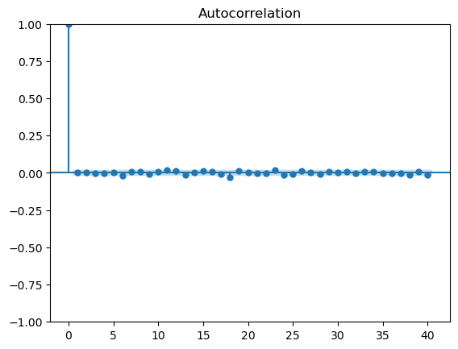

```python
import statsmodels.tsa.api as smt #timeseries analysis

acf = smt.graphics.plot_acf(lin_reg.resid, lags=40 , alpha=0.05)#auto_correlation value, lags= previous value
acf.show()
```

Assumption 2- Normality of Residuals 2) The second assumption is the Normality of Residuals / Error terms.

For this we prefer the Jarque Bera test. For a good model, the residuals should be normally distributed. The higher the value of Jarque Bera test , the lesser the residuals are normally distributed. We generally prefer a lower value of jarque bera test.

The Jarque–Bera test is a goodness-of-fit test of whether sample data have the skewness and kurtosis matching a normal distribution. A large value for the jarque-bera test indicates non normality.

The jarque bera test tests whether the sample data has the skewness and kurtosis matching a normal distribution. Note that this test generally works good for large enough number of data samples(>2000) as the test statistics asymptotically has a chi squared distribution with degrees 2 of freedom.

```python
#H0: the error terms are normally distributed
#dof for residuals is n-2
```

```python
from scipy import stats
print(stats.jarque_bera(lin_reg.resid))
```

```
SignificanceResult(statistic=65051.545241382446, pvalue=0.0)
```

The critical chi square value at the 5% level of significance is 5.99. If the computed value exceeds this value the null hypothesis is rejected. In this case the computed value of the JB statistic 65051.11 is greater than 5.99. Thus we reject the null hypothesis that the error terms are normally distributed.

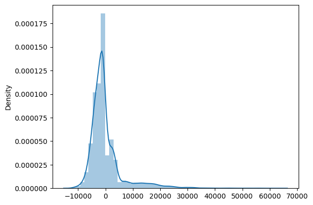

```python
import seaborn as sns

sns.distplot(lin_reg.resid)
plt.show()
```

From the graph we infer that due to the high value of Jarque Bera test, only few residuals are normally distributed

**Asssumption 3 - Linearity of residuals**

```python
import statsmodels.api as sm
sm.stats.diagnostic.linear_rainbow(res=lin_reg, frac=0.5)#the fraction of the data to include in the center model
```

```
(1.0164972729968935, 0.2907128743692436)
```

```python
lin_reg.resid.mean()
```

```
1.6774053542416127e-09
```

Assumption 4 - Homoscedasticity_test(using goldfeld test) OR (Beusch-Wagon Test) Homoscedacity :: If the variance of the residuals are symmetrically distributed across the regression line , then the data is said to homoscedastic.

Heteroscedacity :: If the variance is unequal for the residuals across the regression line, then the data is said to be heteroscedastic. In this case the residuals can form an arrow shape or any other non symmetrical shape.

This test is based on the hytpothesis testing where null and alternate hypothesis are: 𝐻0:𝜎𝑢𝑖 𝑖𝑠 𝑐𝑜𝑛𝑠𝑡𝑎𝑛𝑡 𝑎𝑐𝑟𝑜𝑠𝑠 𝑡ℎ𝑒 𝑟𝑎𝑛𝑔𝑒 𝑜𝑓 𝑑𝑎𝑡𝑎 𝐻𝑎:𝜎𝑢𝑖 𝑖𝑠 𝑛𝑜𝑡 𝑐𝑜𝑛𝑠𝑡𝑎𝑛𝑡 𝑎𝑐𝑟𝑜𝑠𝑠 𝑡ℎ𝑒 𝑟𝑎𝑛𝑔𝑒 𝑜𝑓 𝑑𝑎𝑡𝑎 The residuals should be homoscedastic.

Goldfeld Test

```python
import statsmodels.stats.api as sms
```

```python
name=['F-statistic','p-value']
test=sms.het_goldfeldquandt(lin_reg.resid,lin_reg.model.exog)

test
```

```
(1.2289680194898225, 2.216740369946362e-12, 'increasing')
```

p-value below a certain level (like 0.05) indicates we should reject the null in favor of heteroscedasticity.

#### Assumption 5- NO MULTI COLLINEARITY

The interpretation of VIF is as follows: the square root of a given variable’s VIF shows how much larger the standard error is, compared with what it would be if that predictor were uncorrelated with the other features in the model. If no features are correlated, then all values for VIF will be 1.

```python
from statsmodels.stats.outliers_influence import variance_inflation_factor
vif = [variance_inflation_factor(X_constant.values, i) for i in range(X_constant.shape[1])]
pd.DataFrame({'vif': vif[1:]}, index=X.columns)
```

|  | vif |
| --- | --- |
| Income | 3.183923 |
| Monthly Premium Auto | 27.569851 |
| Months Since Last Claim | 1.009934 |
| Months Since Policy Inception | 1.022048 |
| Total Claim Amount | 4.396905 |
| Number of Open Complaints | 1.009196 |
| Number of Policies | 1.019460 |
| State_California | 1.878492 |
| State_Nevada | 1.378696 |
| State_Oregon | 1.813907 |
| State_Washington | 1.346631 |
| Response_Yes | 1.223327 |
| Coverage_Extended | 3.025019 |
| Coverage_Premium | 5.293859 |
| Education_College | 1.408609 |
| Education_Doctor | 1.100259 |
| Education_High School or Below | 1.426087 |
| Education_Master | 1.193819 |
| EmploymentStatus_Employed | 6.832471 |
| EmploymentStatus_Medical Leave | 1.986035 |
| EmploymentStatus_Retired | 1.752228 |
| EmploymentStatus_Unemployed | 5.610118 |
| Gender_M | 1.023864 |
| Location Code_Suburban | 3.735429 |
| Location Code_Urban | 1.933874 |
| Marital Status_Married | 2.141867 |
| Marital Status_Single | 2.327253 |
| Policy Type_Personal Auto | inf |
| Policy Type_Special Auto | inf |
| Policy_Corporate L2 | 2.495167 |
| Policy_Corporate L3 | 3.414004 |
| Policy_Personal L1 | inf |
| Policy_Personal L2 | inf |
| Policy_Personal L3 | inf |
| Policy_Special L1 | inf |
| Policy_Special L2 | inf |
| Policy_Special L3 | inf |
| Renew Offer Type_Offer2 | 1.379520 |
| Renew Offer Type_Offer3 | 1.228733 |
| Renew Offer Type_Offer4 | 1.255994 |
| Sales Channel_Branch | 1.271889 |
| Sales Channel_Call Center | 1.252330 |
| Sales Channel_Web | 1.220698 |
| Vehicle Class_Luxury Car | 7.781484 |
| Vehicle Class_Luxury SUV | 8.611290 |
| Vehicle Class_SUV | 7.645435 |
| Vehicle Class_Sports Car | 3.220140 |
| Vehicle Class_Two-Door Car | 1.124315 |
| Vehicle Size_Medsize | 2.334500 |
| Vehicle Size_Small | 2.360275 |

we can see that there is high VIF in column Policy & policy type Also we have seen in statistical approach these veriables are not significant to predict target hence from above 2 conclusion we can remove them

```python
from sklearn.model_selection import train_test_split
X=dfn.drop(['CLV','Policy Type_Personal Auto','Policy Type_Special Auto','Policy_Personal L1','Policy_Personal L2','Policy_Personal L3',
'Policy_Special L1','Policy_Special L2','Policy_Special L3'],axis=1)
y=dfn['CLV']
y =np.log(y)
X_train,X_test,y_train,y_test=train_test_split(X,y,test_size=0.30,random_state=42)
```

```python
numerical_cols.rename(columns={'CLV':'CLV'},inplace=True)
```

```python
print(X_train.shape)
print(y_train.shape)
print(X_test.shape)
print(y_test.shape)
```

```
(6393, 42)
(6393,)
(2741, 42)
(2741,)
```

## Linear Regression

```python
from sklearn.linear_model import LinearRegression
```

```python
lr = LinearRegression()
model = lr.fit(X_train,y_train)
print(f'R^2 score for train: {lr.score(X_train, y_train)}')
print(f'R^2 score for test: {lr.score(X_test, y_test)}')
```

```
R^2 score for train: 0.26073373730563165
R^2 score for test: 0.2548416026499797
```

```python
y_pred = model.predict(X_test)
```

```python
from sklearn.metrics import mean_squared_error,r2_score,mean_absolute_error
```

```python
print('RMSE:',np.sqrt(mean_squared_error(y_test,y_pred)))
print("MAE",mean_absolute_error(y_test,y_pred))
print('R-squared:',r2_score(y_test,y_pred))
```

```
RMSE: 0.5772314153487259
MAE 0.4455033282270872
R-squared: 0.2548416026499797
```

```python
#Feature Selection by Recursive Backward Elimination
cols = list(X.columns)
pmax = 1
while (len(cols)>0):
    p= []
    X = X[cols]
    Xc = sm.add_constant(X)
    model = sm.OLS(y,Xc).fit()
    p = pd.Series(model.pvalues.values[1:],index = cols)
    pmax = max(p)
    feature_with_p_max = p.idxmax()
    if(pmax>0.05):
        cols.remove(feature_with_p_max)
    else:
        break
selected_features = cols
print(selected_features)
```

[output not shown]

```python
X_new = X[['Monthly Premium Auto', 'Number of Open Complaints', 'Number of Policies', 'Coverage_Extended', 'Coverage_Premium', 'Education_High School or Below', 'EmploymentStatus_Employed', 'Marital Status_Single', 'Policy_Corporate L2', 'Renew Offer Type_Offer2', 'Renew Offer Type_Offer3', 'Renew Offer Type_Offer4', 'Vehicle Class_SUV', 'Vehicle Class_Sports Car']]
```

```python
X_constant_new=sm.add_constant(X_new)
lin_reg=sm.OLS(y,X_constant_new).fit()
lin_reg.summary()
```

OLS Regression Results

| Dep. Variable: | CLV | R-squared: | 0.259 |
| --- | --- | --- | --- |
| Model: | OLS | Adj. R-squared: | 0.258 |
| Method: | Least Squares | F-statistic: | 228.2 |
| Date: | Wed, 06 Mar 2024 | Prob (F-statistic): | 0.00 |
| Time: | 10:42:55 | Log-Likelihood: | -7694.3 |
| No. Observations: | 9134 | AIC: | 1.542e+04 |
| Df Residuals: | 9119 | BIC: | 1.553e+04 |
| Df Model: | 14 |  |  |
| Covariance Type: | nonrobust |  |  |

|  | coef | std err | t | P>\|t\| | [0.025 | 0.975] |
| --- | --- | --- | --- | --- | --- | --- |
| const | 7.9001 | 0.024 | 333.289 | 0.000 | 7.854 | 7.947 |
| Monthly Premium Auto | 0.0070 | 0.000 | 30.864 | 0.000 | 0.007 | 0.007 |
| Number of Open Complaints | -0.0317 | 0.006 | -4.895 | 0.000 | -0.044 | -0.019 |
| Number of Policies | 0.0529 | 0.002 | 21.385 | 0.000 | 0.048 | 0.058 |
| Coverage_Extended | 0.0669 | 0.014 | 4.773 | 0.000 | 0.039 | 0.094 |
| Coverage_Premium | 0.0898 | 0.024 | 3.729 | 0.000 | 0.043 | 0.137 |
| Education_High School or Below | 0.0336 | 0.013 | 2.567 | 0.010 | 0.008 | 0.059 |
| EmploymentStatus_Employed | 0.0922 | 0.013 | 7.093 | 0.000 | 0.067 | 0.118 |
| Marital Status_Single | -0.0506 | 0.014 | -3.622 | 0.000 | -0.078 | -0.023 |
| Policy_Corporate L2 | -0.0548 | 0.024 | -2.295 | 0.022 | -0.102 | -0.008 |
| Renew Offer Type_Offer2 | -0.1199 | 0.014 | -8.370 | 0.000 | -0.148 | -0.092 |
| Renew Offer Type_Offer3 | -0.0602 | 0.018 | -3.416 | 0.001 | -0.095 | -0.026 |
| Renew Offer Type_Offer4 | -0.1327 | 0.020 | -6.541 | 0.000 | -0.172 | -0.093 |
| Vehicle Class_SUV | 0.1502 | 0.017 | 8.777 | 0.000 | 0.117 | 0.184 |
| Vehicle Class_Sports Car | 0.1510 | 0.028 | 5.429 | 0.000 | 0.096 | 0.205 |

| Omnibus: | 1476.101 | Durbin-Watson: | 2.019 |
| --- | --- | --- | --- |
| Prob(Omnibus): | 0.000 | Jarque-Bera (JB): | 2293.969 |
| Skew: | 1.163 | Prob(JB): | 0.00 |
| Kurtosis: | 3.788 | Cond. No. | 516. |

Notes:  
[1] Standard Errors assume that the covariance matrix of the errors is correctly specified.

## Rigde and Lasso Regression¶

```python
ridge.fit(X_train,y_train)
print('Ridge Regression')
y_pred = ridge.predict(X_test)
print('RMSE:', np.sqrt(mean_squared_error(y_test, y_pred)))
print('R-squared:',r2_score(y_test,y_pred))
```

```
Ridge Regression
RMSE: 0.5708820866174648
R-squared: 0.26397023688455323
```

```python
ridge.fit(X_train,y_train)
print('Ridge Regression')
y_pred = ridge.predict(X_test)
print('RMSE:', np.sqrt(mean_squared_error(y_test, y_pred)))
print('R-squared:',r2_score(y_test,y_pred))
```

```
Ridge Regression
RMSE: 0.5708820866174648
R-squared: 0.26397023688455323
```

```python
lasso = Lasso(random_state=1)
lasso.fit(X_train,y_train)
print('Ridge Regression')
y_pred = lasso.predict(X_test)
print('RMSE:', np.sqrt(mean_squared_error(y_test, y_pred)))
print('R-squared:',r2_score(y_test,y_pred))
```

```
Ridge Regression
RMSE: 0.5986580602819505
R-squared: 0.19060556642241555
```

## Decision Tree

```python
from sklearn.tree import DecisionTreeRegressor
```

```python
dt = DecisionTreeRegressor(random_state=1)

dt.fit(X_train,y_train)
y_pred=dt.predict(X_test)
print('RMSE:',np.sqrt(mean_squared_error(y_test,y_pred)))
print("MAE",mean_absolute_error(y_test,y_pred))
print('R-squared:',r2_score(y_test,y_pred))
```

```
RMSE: 0.26681132860292806
MAE 0.11161560831714162
R-squared: 0.8392277551489291
```

## RandomForest

```python
from sklearn.ensemble import RandomForestRegressor
```

```python
rf = RandomForestRegressor(random_state=1)

rf.fit(X_train,y_train)

y_pred=rf.predict(X_test)
print('RMSE:',np.sqrt(mean_squared_error(y_test,y_pred)))
print("MAE",mean_absolute_error(y_test,y_pred))
print('R-squared:',r2_score(y_test,y_pred))
```

```
RMSE: 0.21435660670160195
MAE 0.09702429632200531
R-squared: 0.8962289307033796
```

## Hyperparameter tuning of random forest

```python
from sklearn.model_selection import GridSearchCV
rf = RandomForestRegressor()
params = {
        'max_depth' : [10,20,30],

        'n_estimators' : [200,300,50],

        "bootstrap" : [True, False],

        'max_features': ['auto', 'sqrt', 'log2']

        }

grid = GridSearchCV(estimator = rf, param_grid=params, cv = 5, n_jobs = -1, return_train_score = True )
grid.fit(X,y)
grid.best_params_
```

```
{'bootstrap': True,
 'max_depth': 10,
 'max_features': 'auto',
 'n_estimators': 200}
```

```python
rf = RandomForestRegressor(**grid.best_params_)

rf.fit(X_train,y_train)

y_pred=rf.predict(X_test)
print('RMSE:',np.sqrt(mean_squared_error(y_test,y_pred)))
print("MAE",mean_absolute_error(y_test,y_pred))
print('R-squared:',r2_score(y_test,y_pred))
```

```
RMSE: 0.20636332800461438
MAE 0.10082736558960585
R-squared: 0.9038238050114588
```

```python
from sklearn.ensemble import AdaBoostRegressor
```

```python
from sklearn.ensemble import AdaBoostRegressor
from sklearn.ensemble import RandomForestRegressor
from sklearn.model_selection import train_test_split

# Assuming X_train and y_train are your training data
X_train, X_test, y_train, y_test = train_test_split(X, y, test_size=0.2, random_state=42)

adaboost = AdaBoostRegressor(
    base_estimator=RandomForestRegressor(max_depth=5, criterion='squared_error'),
    n_estimators=150
)

adaboost.fit(X_train, y_train)
```

```
AdaBoostRegressor(base_estimator=RandomForestRegressor(max_depth=5),
                  n_estimators=150)
```

```python
y_pred = adaboost.predict(X_test)
print('RMSE:',np.sqrt(mean_squared_error(y_test,y_pred)))
print("MAE",mean_absolute_error(y_test,y_pred))
print('R-squared:',r2_score(y_test,y_pred))
```

```
RMSE: 0.21829568157594567
MAE 0.13087464968493964
R-squared: 0.8923800381626911
```

```python
pd.DataFrame(rf.feature_importances_,index=X.columns,columns=['Score']).sort_values("Score",ascending=False)[:10]
```

|  | Score |
| --- | --- |
| Number of Policies | 0.721957 |
| Monthly Premium Auto | 0.248862 |
| EmploymentStatus_Employed | 0.006712 |
| Number of Open Complaints | 0.005503 |
| Coverage_Extended | 0.003199 |
| Marital Status_Single | 0.003065 |
| Education_High School or Below | 0.002810 |
| Renew Offer Type_Offer2 | 0.002285 |
| Renew Offer Type_Offer3 | 0.001520 |
| Renew Offer Type_Offer4 | 0.001319 |

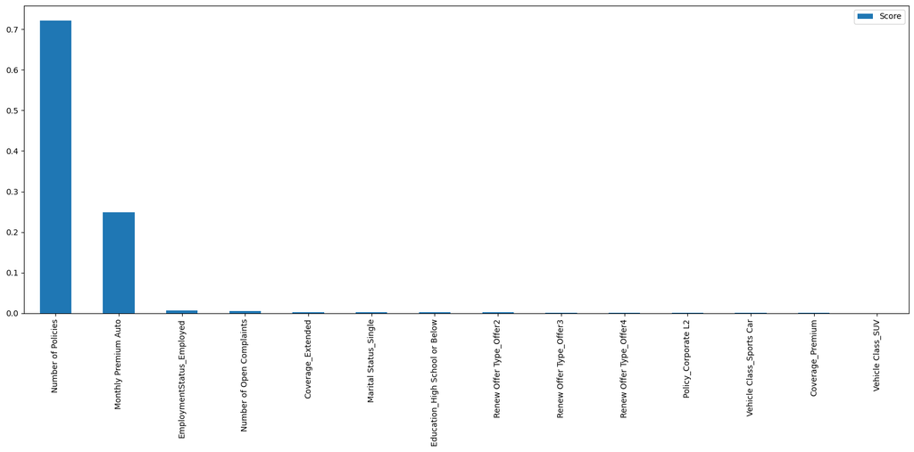

```python
pd.DataFrame(rf.feature_importances_,index=X.columns,columns=['Score']).sort_values("Score",ascending=False).plot(kind='bar',figsize=(20,7))
plt.show()
```

Random Forest Model with hyperparameter tuning using GridSearchCV gave the best RMSE and R^2 score

No of Policies and Monthly Premium are the most important features in predicting CLV